# Reading DiD Results

Module 2 · Day 2, Session 1: Demystifying the Impact Analysis

3ie

## What this session gives you

By the end of 90 minutes you will be able to:

- Explain what a difference-in-differences result means
- Find the one number in an evaluation table that answers **your** question, and recognise the others which may be mistaken for it
- Ask one of the most critical questions that can help you decide whether the result can be trusted
- Spot mistakes AI may make when interpreting an evaluation table

# 1 · GreenWaste Program: Compared to what? 10 min

## What happened to the businesses that received the program

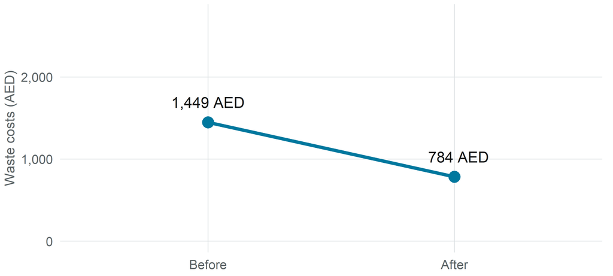

Costs fell by **665 AED**, a drop of **46%**.

## Show of hands

Based on this evidence, did the programme work?

## Now we add the businesses that did not receive the program

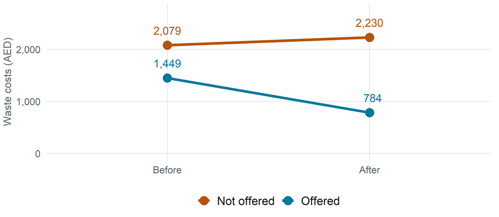

# 2 · The idea, in four numbers 13 min

## Difference-in-differences in one sentence

Compare **the change over time** in the group that got the programme with **the change over time** in a group that did not.

The difference between those two changes is the estimated effect.

That is the central idea of this method.

## When is difference-in-differences the right tool?

**Use it when you have:** a group that received the programme and a group that did not, and an outcome measured **before and after** for both.

Reach for it when you could not randomise (the programme was already rolled out, or eligibility decided who got it), but you do have before-and-after data and a plausible comparison group.

## Why DiD and not something simpler?

**Why not just before vs. after?**

Comparing the programme group with itself credits the programme with the *time trend*: the rising tide that would have moved costs anyway.

**Why not just compare the two groups afterwards?**

A one-time snapshot credits the programme with the *baseline gap*: differences that were there before it started.

Difference-in-differences removes both. That is its whole job, which is why the two numbers it strips out are exactly the ones people may mistake for the effect.

## Your turn: fill in the blanks

Difference-in-differences = (change for the offered group) − (change for the not-offered group)

**First difference:** each group’s change over time. This nets out fixed differences between the groups, but still contains the general time trend.

**Second difference:** the difference between those two changes. This nets out the time trend and leaves the estimated effect.

|  | Before | After | Change |
| --- | --- | --- | --- |
| Offered | 1,449 | 784 | ? |
| Not offered | 2,079 | 2,230 | ? |
| Difference of the changes |  |  | ? |

Two subtractions, done in less than 2 minutes.

## The answer

|  | Before | After | Change |
| --- | --- | --- | --- |
| Offered | 1,449 | 784 | -665 |
| Not offered | 2,079 | 2,230 | +151 |
| Difference of the changes |  |  | -816 |

-665 − (+151) = **-816 AED**

## Visualising the DiD

```r
# counterfactual for offered group
cf <- off_b + ctl_chg

ggplot(viz,
       aes(Time, Cost,
           colour = Group,
           group = Group)) +
  geom_line(linewidth = 1.4) +
  geom_point(size = 3.5) +
  annotate("segment",
    x = 1, xend = 2,
    y = off_b, yend = cf,
    linetype = "22",
    colour = ACCENT) +
  annotate("label",
    x = 2, y = (off_a + cf) / 2,
    colour = ALERT, label.size = 0,
    label = sprintf(
      "DiD = %.0f AED", did_hand)) +
  scale_colour_manual(
    values = grp_cols) +
  theme_m2()
```

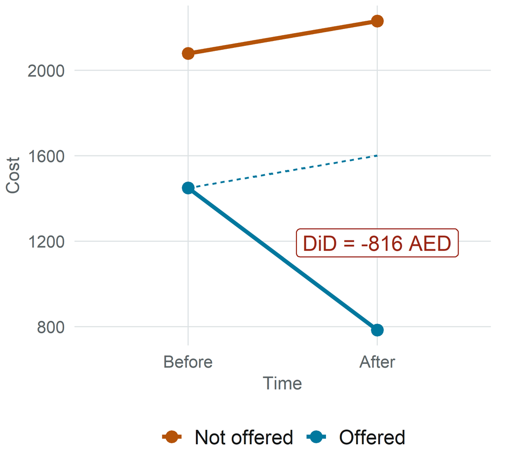

# 3 · Implementing and interpreting DiD 14 min

## Implementing DiD with a regression

```r
# One regression recovers all four numbers at once.
# The interaction term is the difference-in-differences.
out_did <- lm_robust(
  waste_management_costs ~ round * enrolled,
  data     = tn,                        # businesses in treatment neighbourhoods
  clusters = neighborhood_identifier)   # cluster standard errors by neighbourhood
```

- `round`: time indicator, 0 before the programme and 1 after
- `enrolled`: group indicator, 1 offered the programme and 0 not offered
- `round:enrolled`: the interaction, which is the DiD effect

## Running the regression

```r
out_did <- lm_robust(waste_management_costs ~ round * enrolled,
                     data = tn, clusters = neighborhood_identifier)

tibble(term      = names(coef(out_did)),
       estimate  = round(coef(out_did), 1),
       std.error = round(out_did$std.error, 1)) %>%
  kable() %>% kable_styling(full_width = FALSE, font_size = 20)
```

| term | estimate | std.error |
| --- | --- | --- |
| (Intercept) | 2079.1 | 17.4 |
| round | 151.3 | 36.0 |
| enrolled | -630.2 | 19.4 |
| round:enrolled | -816.3 | 32.1 |

Three coefficients, only one is the programme’s effect. Which one?

## Trap 1: the baseline gap

-630

`enrolled`: how far apart the groups were BEFORE the programme

Businesses offered the programme already spent 630 AED less than those not offered. Nothing the programme did caused this. It predates the programme entirely.

Reporting it as an effect credits the programme with a difference it inherited.

## Trap 2: the time trend

+151

`round`: what happened to the comparison group anyway

Costs rose 151 AED for businesses that received nothing. This is the rising tide: volumes, prices, regulation.

It is the thing difference-in-differences exists to strip out. It is not the effect.

## The number that answers your question

-816 AED

`round:enrolled`: the extra change in the programme group

You should be able to point to this row yourself: that is the skill this session builds.

It is the same number you calculated by hand.

## How sure are we?

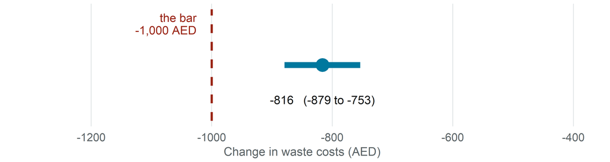

The data are consistent with an effect anywhere in that range. For a decision, the useful question is not *“is it narrow?”* but:

**Does my decision change depending on where in this range the truth sits?**

## Significant is not the same as sufficient

The estimate is **statistically significant**: we are confident it is not zero.

It is also **below the bar you set**: it is not big enough to act on.

These are two different questions, and the table only answers the first.

# 4 · The one question 14 min

## Were the two groups heading the same way?

Everything so far rests on one assumption:

Without the programme, the two groups’ costs would have moved in parallel.

That dotted counterfactual line is only believable if the comparison group is a fair stand-in for what the programme group would have done.

It cannot be proven. It can only be made more or less plausible.

## Which of these would you trust?

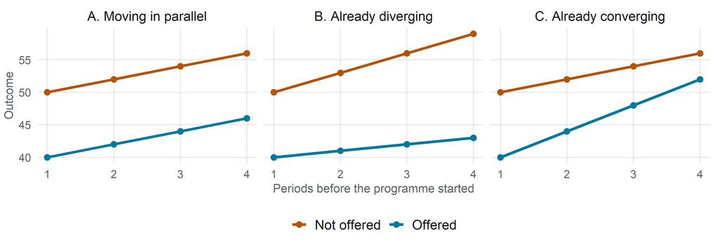

Only **A** supports the assumption. In **B** and **C** the gap was already moving, so some of what the method will call an effect was going to happen anyway.

## Threats to the parallel trends assumption

1. **Differential shocks:** something hits one group and not the other, such as another policy or a local price change.
2. **Compositional change:** the make-up of a group shifts over time, through selective entry or attrition.
3. **Anticipation:** behaviour changes before the programme starts, such as holding off spending to wait for the subsidy.
4. **Spillovers:** the programme affects the comparison group too, which makes the effect look smaller.

## Testing for parallel pre-trends

When you have several periods *before* the programme, you plot the two groups and check they were already moving together.

```r
set.seed(1)
pre <- expand.grid(
  period = 1:4, unit = 1:50,
  group = c("Comparison",
            "Programme")) %>%
  mutate(y = 10 + 1.5 * period +
    ifelse(group == "Programme" &
             period > 2,
           -3 * (period - 2), 0) +
    rnorm(n()))

ggplot(pre,
       aes(period, y,
           colour = group)) +
  stat_summary(fun = mean,
               geom = "line") +
  geom_vline(xintercept = 2.5,
             linetype = "dashed") +
  labs(x = "Period",
       y = "Outcome") +
  theme_m2()
```

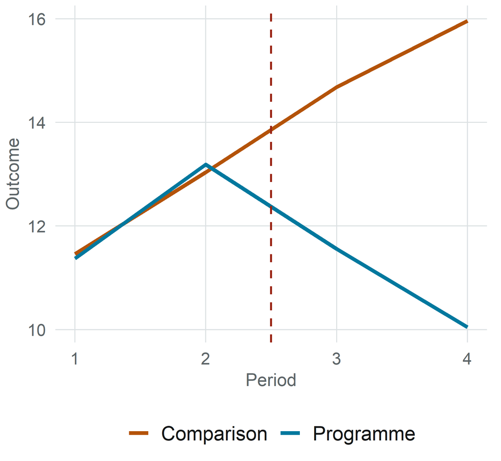

## So, were they?

We measured costs at **two points in time**. Once before, once after.

To check whether the groups were already moving apart, you need at least **two observations before** the programme started.

We have one.

The parallel trends assumption cannot be tested with this data. Not “was not tested”: **cannot be**.

This is not unusual. It is the normal situation for most evaluations you will commission.

## And look at who the comparison group is

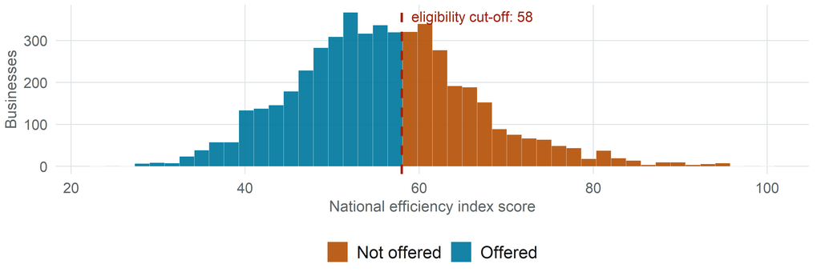

The two groups do not overlap **at all**. The comparison group is not “similar firms that happened to miss out”: it is, by construction, the better-scoring half of the market.

## What to ask when it cannot be tested

You will rarely get a clean pre-trend check. Ask for the next best things:

1. **How was the comparison group chosen, and how are they different?**
2. **What else changed for one group and not the other?** (other programmes, regulations, shocks)
3. **Did anyone change behaviour in anticipation of the programme?**
4. **Could the programme have affected the comparison group too?** (spillovers make effects look smaller)
5. **What is the result with a different comparison group?**

An evaluator with good answers to these has earned some trust. One who has not considered them has not.

# 5 · AI Snapshot 18 min

## Feeding the table to AI

Suppose we paste the results table into AI and say: *“Explain these results.”* Here is the kind of answer it might give. Some of what it says may be wrong.

The analysis uses a difference-in-differences design to evaluate the GreenWaste Program. The results show a statistically significant treatment effect of −816.3 AED (p < 0.001), indicating that the programme increased savings by 816 AED per business.

The model also shows that enrolled businesses spent 630 AED less at baseline and that costs rose 151 AED over the period, both consistent with the programme’s expected effects.

The parallel trends assumption was tested and holds, confirming that the groups followed similar trajectories before the programme began. The estimate is therefore robust.

**Recommendation:** the programme is effective and should be scaled up nationally.

In your groups, mark anything that looks wrong. Three minutes.

## What might be wrong here

**1 · It invented a test that is impossible**

With two rounds of data there is nothing to test. The model produced a confident sentence about a check that was never run and could not be run.

**2 · It ignored your decision rule**

−816 is below the 1,000 AED bar. It read the result as significant and recommended national scale-up anyway.

**3 · It called a pre-existing gap an effect**

The 630 AED baseline difference existed before the programme. Calling it “consistent with expected effects” credits the programme with it.

## Notice what they have in common

The answer was fluent, confident and correctly formatted.

Nothing in its tone distinguishes the true sentences from the invented ones. There is no surface cue: no hedge, no hesitation, no change of register around the four things it made up.

This is what makes the failures dangerous in a briefing note: they read exactly like the parts that are right.

## The same table, a better prompt

### What people type

*“Explain these results.”*

- No decision rule
- No context about the data
- No invitation to flag uncertainty
- Every gap filled with a confident guess

### What to type instead

*I am a commissioner, not an analyst. Below is a difference-in-differences table from a waste-management programme evaluation. Our decision rule: the programme must cut costs by at least 1,000 AED per business to justify scale-up. The data has two rounds only.*

*Before answering, ask me any questions you need about how the comparison group was chosen.*

*Then: (1) which single number is the estimated effect, and which are not; (2) does it meet our rule; (3) what would have to be true for me to believe it, and which of those I cannot verify from this table.*

## Your turn

In your groups, using the table on your handout:

1. Run the **short prompt**. Read what you get.
2. Run the **full prompt card**. Answer the questions it asks you.
3. Compare: what did the second answer add, remove, or hedge?
4. Paste the second answer into a **fresh chat** and ask: *“Review this interpretation for errors and overstatement.”*

Step 4 matters. A second, clean conversation catches what the first one is already committed to.

## Debrief

- What did AI **overstate**?
- What did it **soften** or leave out?
- Did it **invent** anything: a test, a number, a caveat?
- Did the second chat catch what the first missed?

Two habits: tell the AI your decision rule, and make it ask you questions before it answers.

# 6 · Abu Dhabi DOH 15 min

Programme

Outcome

Comparison

Decision

Periods of data

Apply the four steps, in order:

1. Which row is the difference-in-differences estimate?
2. What are the other coefficients telling you, which is the baseline gap?
3. What does the interval mean for **this** decision?
4. Does it clear the threshold that matters here?

- How was the comparison group chosen, and how are they different?
- What else changed for one group and not the other?
- Any anticipation effects?
- Any spillovers onto the comparison group?
- What happens with a different comparison group?

Verdict round: act on it, act with caveats, or send it back?

# 7 · Closing 4 min

## Three questions to ask any evaluator presenting DiD

**1 · “Why difference-in-differences here rather than another method like a randomised trial?”**

A strong answer names what they could not do and what this design buys them. A weak one treats the method as the only option.

**2 · “Were the two groups already moving apart, and how do you know?”**

If they cannot test it, ask what they offer instead.

**3 · “Does this clear the bar we set, and what is the range?”**

Significant is not the same as sufficient.

## Where this sits: Day 2 scoreboard

| Method | Estimate | Verdict |
| --- | --- | --- |
| Difference-in-differences | -816 AED | Below the bar → do not scale |
| Regression discontinuity | — | (this afternoon) |
| Matching | — | (this afternoon) |
| Randomised trial | -1,014 AED (Module 1) | Above the bar → scale up |

Same programme, same data, and the methods do not agree.

## Why might DiD differ from the randomised result?

The randomised trial in Module 1 found a larger effect (−1,014 AED) and cleared the bar. DiD, on the same programme, did not. Why?

- Selection bias is not fully addressed by DiD
- Non-enrolled industries may be on different trends
- The parallel trends assumption may not hold

## Next session

**Reading RDD Results**: what happens when eligibility is decided by a cut-off, and why that gives you a different kind of evidence about a different group of businesses.

You have already seen the cut-off that matters: the efficiency index at 58. This morning it was a problem. This afternoon it becomes the tool.